# Лабораторная работа № 14

Партиции, файловые системы, монтирование

Павличенко Родион Андреевич

1132246838@pfur.ru

Российский университет дружбы народов

# Информация

## Докладчик

- Павличенко Родион Андреевич
- Cтудент
- Группа НПИбд-02-24
- Российский университет дружбы народов им. П. Лумумбы
- 1132246838@pfur.ru

# Цель работы

## Цель лабораторной работы

- Получить навыки создания разделов на диске и файловых систем
- Получить навыки монтирования файловых систем

# Выполнение лабораторной работы

## Добавление дисков

Добавили к виртуальной машине два диска размером 512 МБ

[figure not shown]

## Просмотр разделов

Запустили виртуальную машину и просмотрели перечень разделов с помощью fdisk

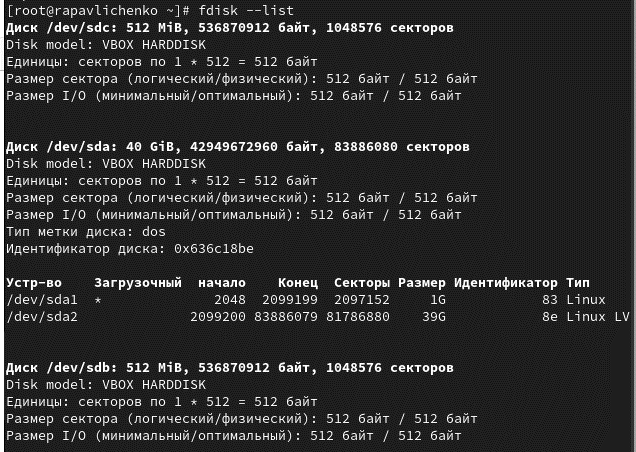

## Справка по командам fdisk

Запустили fdisk /dev/sdb и получили справку по командам

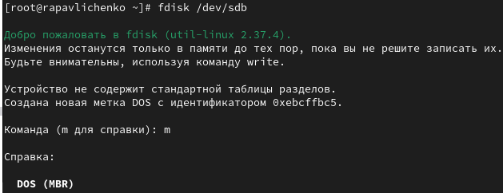

## Создание основного раздела

Создали основной раздел с помощью команды n и настроили параметры

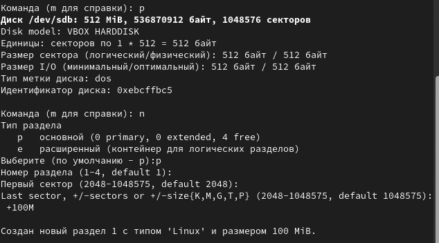

## Изменение типа раздела

Изменили тип раздела командой t и записали изменения

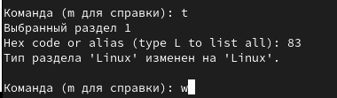

## Сравнение информации о разделах

Сравнили вывод fdisk -l /dev/sdb с cat /proc/partitions

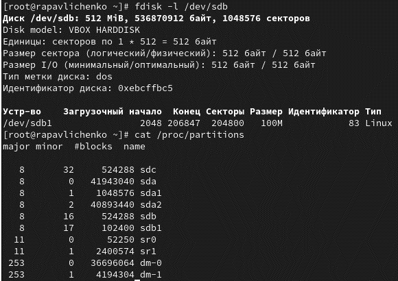

## Обновление таблицы разделов

Записали изменения в таблицу разделов ядра

## Создание расширенного раздела

Создали расширенный раздел с помощью команды e

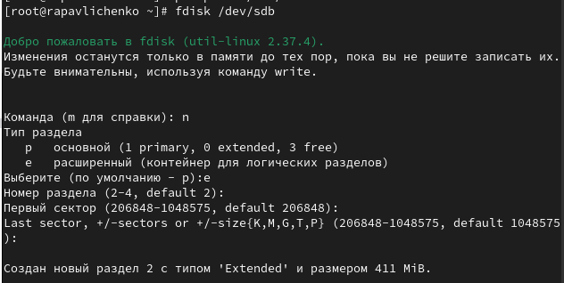

## Создание логического раздела

Создали логический раздел с номером 5 размером 101M

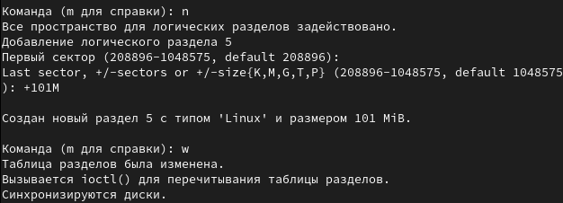

## Обновление таблицы разделов

Обновили таблицу разделов командой partprobe

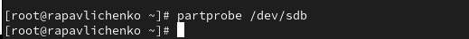

## Просмотр информации о разделах

Просмотрели информацию о добавленных разделах

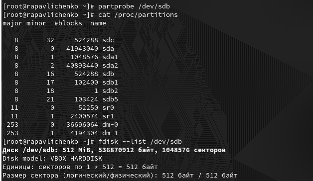

## Создание логического раздела 6

Создали второй логический раздел размером 100M

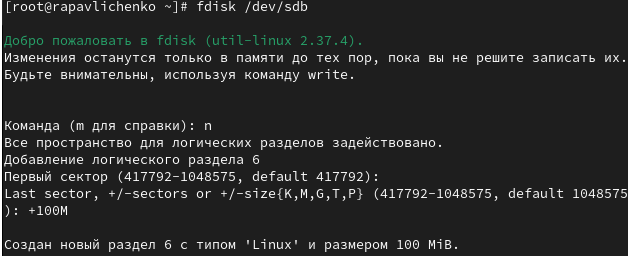

## Изменение типа раздела 6

Изменили тип раздела для раздела с номером 6

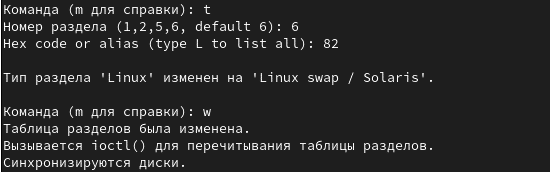

## Обновление таблицы разделов

Обновили таблицу разделов ядра

## Просмотр информации о разделах

Проверили информацию о всех созданных разделах

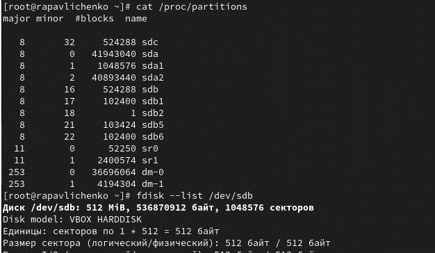

## Форматирование раздела подкачки

Отформатировали раздел подкачки и активировали его

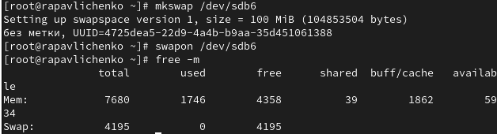

## Работа с GPT разделами

Просмотрели таблицы разделов GPT на диске /dev/sdc

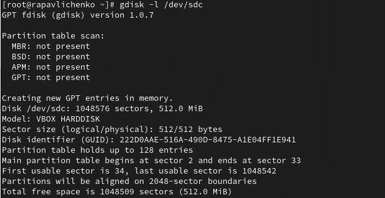

## Создание GPT раздела

Создали раздел с помощью gdisk размером 100 MiB

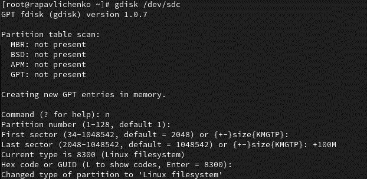

## Просмотр разбиения диска

Просмотрели планируемую таблицу разделов

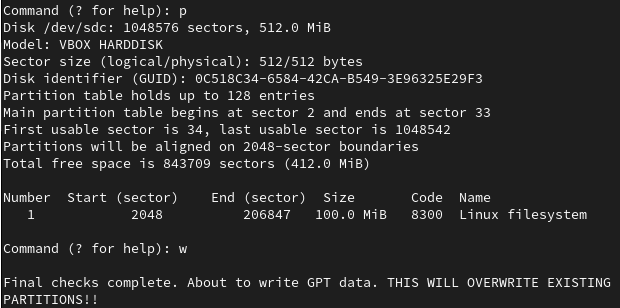

## Обновление таблицы разделов

Обновили таблицу разделов для диска /dev/sdc

## Просмотр информации о GPT разделах

Проверили информацию о созданных GPT разделах

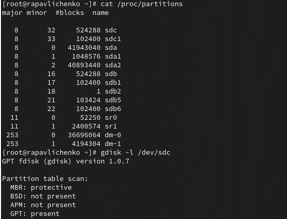

## Создание файловой системы XFS

Создали файловую систему XFS на /dev/sdb1

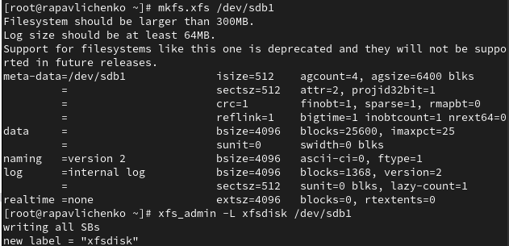

## Создание файловой системы EXT4

Создали файловую систему EXT4 на /dev/sdb5

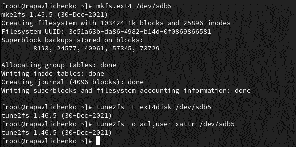

## Монтирование файловой системы

Создали точку монтирования и смонтировали файловую систему

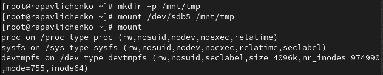

## Отмонтирование раздела

Отмонтировали раздел с помощью команды umount

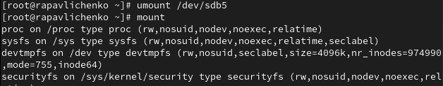

## Работа с UUID

Создали точку монтирования для XFS и посмотрели UUID

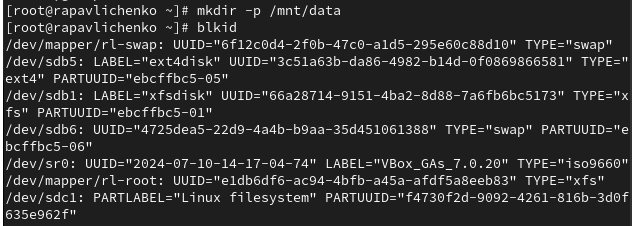

## Копирование UUID

Скопировали UUID устройства /dev/sdb1

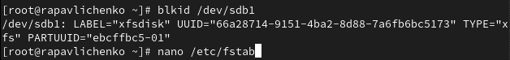

## Редактирование fstab

Отредактировали файл /etc/fstab для автоматического монтирования

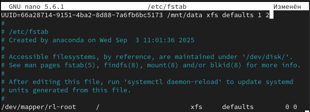

## Проверка монтирования

Проверили корректность монтирования командой df -h

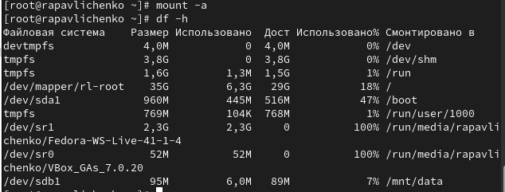